# Updates on bias estimation in the Vivo-vitro experiment

Michael McLaren

2020-12-08

Phyloseq object subset to just the fecal samples and 11 focal species,

```r
ps0
```

```
#> phyloseq-class experiment-level object
#> otu_table()   OTU Table:          [ 11 taxa and 220 samples ]:
#> sample_data() Sample Data:        [ 220 samples by 25 sample variables ]:
#> tax_table()   Taxonomy Table:     [ 11 taxa by 10 taxonomic ranks ]:
#> phy_tree()    Phylogenetic Tree:  [ 11 tips and 10 internal nodes ]:
#> refseq()      DNAStringSet:       [ 11 reference sequences ]
#> taxa are columns
```

| specimen_type | n |
| --- | --- |
| Fecal | 220 |

- *E. rectale* and *F. prausnitzii* are excluded
- The two *E. coli* strains are aggregated to the species level

and 16 batch-protocol combinations (Extraction batch X Extraction protocol X Sequencing center),

| extraction_batch | n |
| --- | --- |
| B1 | 110 |
| B2 | 110 |

| extraction_protocol | n |
| --- | --- |
| E1 | 110 |
| E2 | 110 |

| center_id | library_strategy | n |
| --- | --- | --- |
| A1 | Amplicon | 60 |
| A2 | Amplicon | 46 |
| S1 | Shotgun | 54 |
| S2 | Shotgun | 60 |

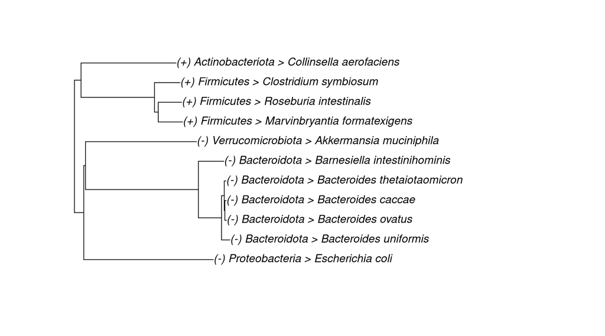

## Absolute vs. relative changes in log bias

In our last meeting, I argued that not just the absolute change in log-bias between the fecal and inoculum samples, but also the relative change, mattered for the goals of the Vivo-vitro experiment. Here is a clearer explanation of my reasoning. The bottom line is that the change in bias between control and target sample types determines the remaining compositional error after calibration. As long as the change in bias between sample types is smaller than the bias within the target sample type, calibration reduces compositional error.

Consider calibration of target samples that are measured by a protocol with bias vector (i.e., vector of relative efficiencies) $B$. However, due to differences between the control samples and the target samples, our estimate of bias $\hat B$ differs from the true bias by $\Delta$: $\mathop{\mathrm{clr}}\hat B = \mathop{\mathrm{clr}}B + \mathop{\mathrm{clr}}\Delta$. Consider a target sample with actual and observed relative abundances given by $A$ and $O$, such that $\mathop{\mathrm{clr}}O = \mathop{\mathrm{clr}}A + \mathop{\mathrm{clr}}B$. When we use $\hat B$ to calibrate there will be a remaining error given by $\Delta$.

$$\begin{align}
\mathop{\mathrm{clr}}\hat A &= \mathop{\mathrm{clr}}O - \mathop{\mathrm{clr}}\hat B
\\&= \mathop{\mathrm{clr}}O - (\mathop{\mathrm{clr}}B + \mathop{\mathrm{clr}}\Delta)
\\&= \mathop{\mathrm{clr}}A - \mathop{\mathrm{clr}}\Delta
\end{align}$$

Calibration has changed the measurement error, as quantified by the difference between the true and estimated value of $\mathop{\mathrm{clr}}A$, from $\mathop{\mathrm{clr}}B$ to $\mathop{\mathrm{clr}}\Delta$. Therefore, even if the difference in bias between the control and target samples, $\Delta$, is substantial, if it is smaller in magnitude than the bias $B$ then calibration still leads to a significantly more accurate estimate of relative abundances.

## Visualize protocol similarity

```r
sam %>% count(batch_protocol) %>% head
```

```
#> # A tibble: 6 x 2
#>   batch_protocol     n
#>   <fct>          <int>
#> 1 Ref               30
#> 2 B1:E1:A2          12
#> 3 B1:E1:S1          14
#> 4 B1:E1:S2          15
#> 5 B1:E2:A1          15
#> 6 B1:E2:A2          10
```

```r
fit1 <- complm(
  ps0 %>% transform_sample_counts(~. + 1),
  ~ 0 + specimen_id + batch_protocol,
  boot = FALSE,
  clusters = sample_data(ps0)$specimen_id,
  strata = sample_data(ps0)$extraction_batch
)
X <- model.matrix(terms(fit1), model.frame(fit1))
t(head(X))
```

```
#>                        1 2 3 4 5 6
#> specimen_id5           0 0 0 0 0 0
#> specimen_id6           0 0 0 0 0 0
#> specimen_id7           0 0 0 0 0 0
#> specimen_id8           0 0 0 0 0 0
#> specimen_id9           0 0 0 0 0 0
#> specimen_id10          1 1 1 1 0 0
#> specimen_id11          0 0 0 0 1 1
#> specimen_id12          0 0 0 0 0 0
#> specimen_id17          0 0 0 0 0 0
#> specimen_id18          0 0 0 0 0 0
#> specimen_id19          0 0 0 0 0 0
#> specimen_id20          0 0 0 0 0 0
#> specimen_id21          0 0 0 0 0 0
#> specimen_id22          0 0 0 0 0 0
#> specimen_id23          0 0 0 0 0 0
#> specimen_id24          0 0 0 0 0 0
#> batch_protocolB1:E1:A2 0 0 0 0 0 0
#> batch_protocolB1:E1:S1 0 0 0 0 0 0
#> batch_protocolB1:E1:S2 0 0 0 0 0 0
#> batch_protocolB1:E2:A1 0 1 0 1 0 1
#> batch_protocolB1:E2:A2 0 0 0 0 0 0
#> batch_protocolB1:E2:S1 0 0 0 0 0 0
#> batch_protocolB1:E2:S2 0 0 0 0 0 0
#> batch_protocolB2:E1:A2 0 0 0 0 0 0
#> batch_protocolB2:E1:S1 0 0 0 0 0 0
#> batch_protocolB2:E1:S2 0 0 0 0 0 0
#> batch_protocolB2:E2:A1 0 0 0 0 0 0
#> batch_protocolB2:E2:A2 0 0 0 0 0 0
#> batch_protocolB2:E2:S1 0 0 0 0 0 0
#> batch_protocolB2:E2:S2 0 0 0 0 0 0
```

To visualize differential bias while still getting a feel for the variability in the raw data, we can work with the observed data after subtracting the corresponding estimated specimen effects.

```r
specimens <- str_c("specimen_id", fit1$model$specimen_id)
otu <- otu_table(fit1$observed - coef(fit1)[,specimens], taxa_are_rows = TRUE)
```

PCA with equal weighting to each batch:protocol combination,

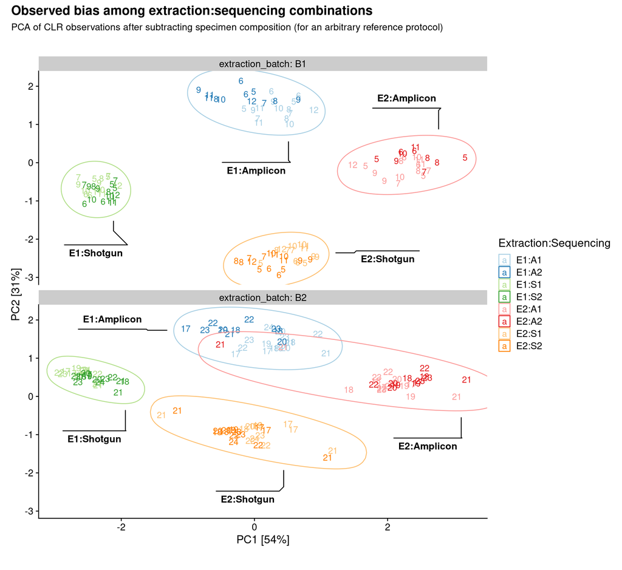

Notes

- Because the specimen compositions vary only slightly, a similar pattern is be seen from PCA using the original observations, with some additional structure within the protocol clusters.
- Including E. rectale leads to a split within clusters between male and female mice consistenly (batch 1) and less consistently (batch 2)
- The PCA indicates a possible mislabeling of samples in Batch 2.
- These compositions are in based on insert (read-pair) counts; therefore Amplicon:Shotgun bias of the form (16S copy number / genome length) is expected

From email: The PCA is showing a type of analysis/plot I mentioned in our call last week as a simple graphical way of visualizing bias in the raw observations. Starting from the observations as CLR vectors I subtract out the specimen effect from each sample (i.e., the composition that would have been measured by the reference protocol E1:A1); under the MWC model, all that is left is the specimen-independent, protocol-associated effects. Here you can see that on the whole, the bias associated with extraction is roughly independent of sequencing center and vice versa, at least within an extraction batch, and the bias associated with extraction protocol and sequencing strategy (amplicon vs shotgun) are much larger than any bias between sequencing centers of the same strategy.

## Differential extraction bias across centers

Question: Is differential extraction bias consistent across different sequencing protocols/centers? Strategy: Estimate the log-bias vector (P2 - P1 | Center) for each of the four sequencing centers. For now, restrict to just the first extraction batch.

I will model the observed clr value of the i-th taxon with the linear model of the form `~ 0 + specimen_id + center_id + extraction_protocol:center_id`,

```r
fit2 <- ps0 %>%
  transform_sample_counts(~. + 1) %>%
  subset_samples(extraction_batch == "B1") %>%
  complm(
    .,
    ~ 0 + specimen_id + center_id + extraction_protocol:center_id,
    boot = TRUE,
    clusters = sample_data(.)$specimen_id
  )
```

Check the head of the model matrix:

```r
X <- model.matrix(terms(fit2), model.frame(fit2))
t(head(X))
```

```
#>                                   1 2 3 4 5 6
#> specimen_id5                      0 0 0 0 0 0
#> specimen_id6                      0 0 0 0 0 0
#> specimen_id7                      0 0 0 0 0 0
#> specimen_id8                      0 0 0 0 0 0
#> specimen_id9                      0 0 0 0 0 0
#> specimen_id10                     1 1 1 1 0 0
#> specimen_id11                     0 0 0 0 1 1
#> specimen_id12                     0 0 0 0 0 0
#> center_idA2                       0 0 0 0 0 0
#> center_idS1                       0 0 0 0 0 0
#> center_idS2                       0 0 0 0 0 0
#> center_idA1:extraction_protocolE2 0 1 0 1 0 1
#> center_idA2:extraction_protocolE2 0 0 0 0 0 0
#> center_idS1:extraction_protocolE2 0 0 0 0 0 0
#> center_idS2:extraction_protocolE2 0 0 0 0 0 0
```

The specimen terms denote the clr-composition measured by the reference protocol, which here is E1:A1. The `center_id` main effect terms capture the differential bias between that center and A1 under the E1 protocol. The interaction terms give the differential extraction bias (E2/E1) in the given sequencing center. To see why the interaction terms are the E2/E1 differential bias: Consider comapring a specimen 5, A2:E1 sample to a specimen 5, A2:E2 sample; the only difference in the mean model is the addition of the coefficient for the `center_idA2:extraction_protocolE2` term.

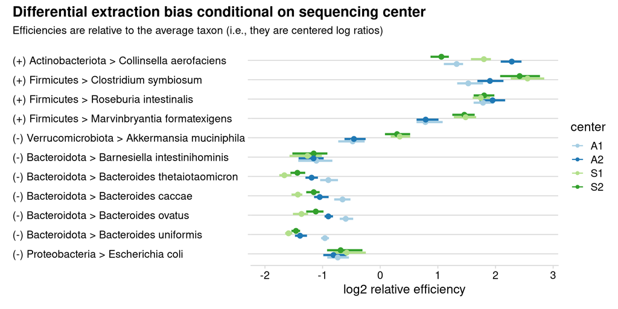

- This is for extraction batch 1
- I am leaving out E. rectale since it appears to violate the model (it does not have a consistent differential bias among specimens within a batch)
- Taxa are ordered phylogenetically, and major grouping is shown by phylum names. A Bacteroides:Firmicutes bias is apparent, which is perhaps to be expected given the known differences between Gram+/- regarding extraction
- The chosen reference tax(a/on) doesn’t affect how we interpret differences between values of different taxa within a center; however, it does affect our interpretation of differences between values between centers.

From email:

> The second figure shows estimated differential extraction bias within each sequencing center. The taxa are ordered by phylogeny and labeled by phylum and Gram type (+/-). Note, Gram type is confounded with phylum - the Actinobacteria and Firmicutes species are + and the rest are -. There are at least 2 big takeaways: 1) Consistent with the PCA, you can see that differential extraction bias is fairly consistent across sequencing centers and 2) differential extraction bias is heavily associated with phylogeny and Gram type.

### Mutually consistent interpretations

From email:

> There are still some challenges to interpretation posed by the relative nature of bias; for example, the difference you point to in Akkermansia muciniphila (the Verrucomicrobiota) could be an artefact of what’s happening with all the other taxa (though I doubt it). The Bacteroides taxa are another good example: They all have a higher efficiency in A1 relative to the average taxon, but this is perhaps being driven by lower absolute A1 efficiencies in Akkermansia, Marvinbryantia, etc.

> The core interpretability challenge with this plot can perhaps be summarized as: I could shift all of the efficiency values of a given sequencing center by a fixed amount (e.g. so that the Bacteroidetes values line up across centers) without changing the implied bias, but it changes the suggested interpretation

To demonstrate this interpretability challenge, we can view the same estimates with different taxonomic references.

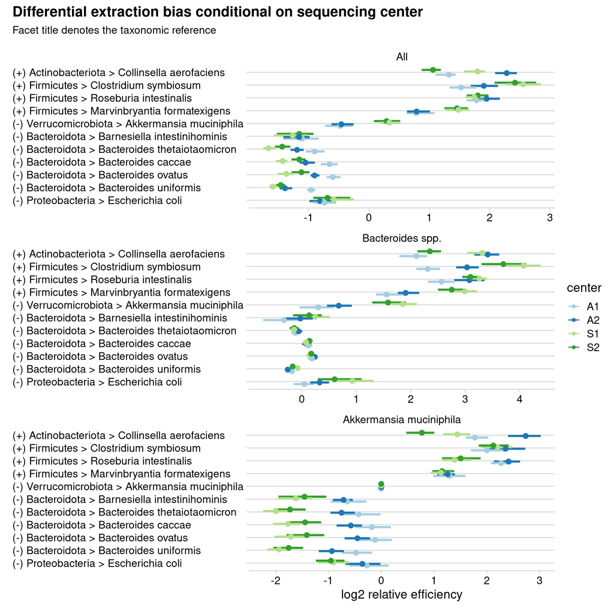

### Relative vs. absolute changes in bias

The above plot shows that there are substantial deviations in the E2/E1 bias across sequencing center, but that these deviations are smaller in magnitude than the E2/E1 bias within centers.

This example provides a clear illustration of a case where the relative log-bias deviation is of interest, not the absolute log-bias deviation.

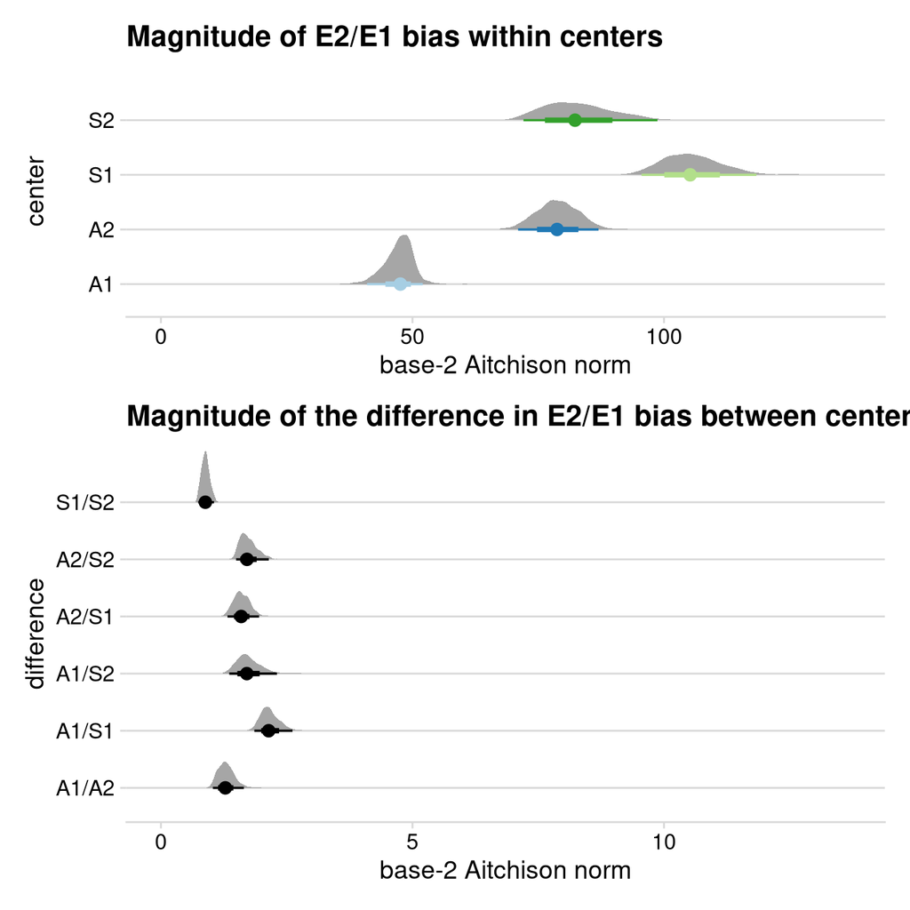

Can see that, despite there being noticeable inconsistency in differential extraction bias across sequencing centers, the overall magnitude of the inconsistency is more than 10X smaller than the differential extraction bias itself.

Other observations: the difference in diff’l bias is smaller between centers of the same sequencing type. This makes sense, but wasn’t a priori obvious - at least not as much as for the differential bias between sequencing centers.

### Plotting the fitted model with the data

One approach is to plot the observed and predicted abundance of an individual taxon as measured by the various protocols on the y axis against the the predicted measurement by a chosen reference protocol on the x axis.

Using fixed coordinates allows seeing the radically different ranges of the different taxa, and make it clear that the slopes of the lines are always 1, and bias just changes the intercept

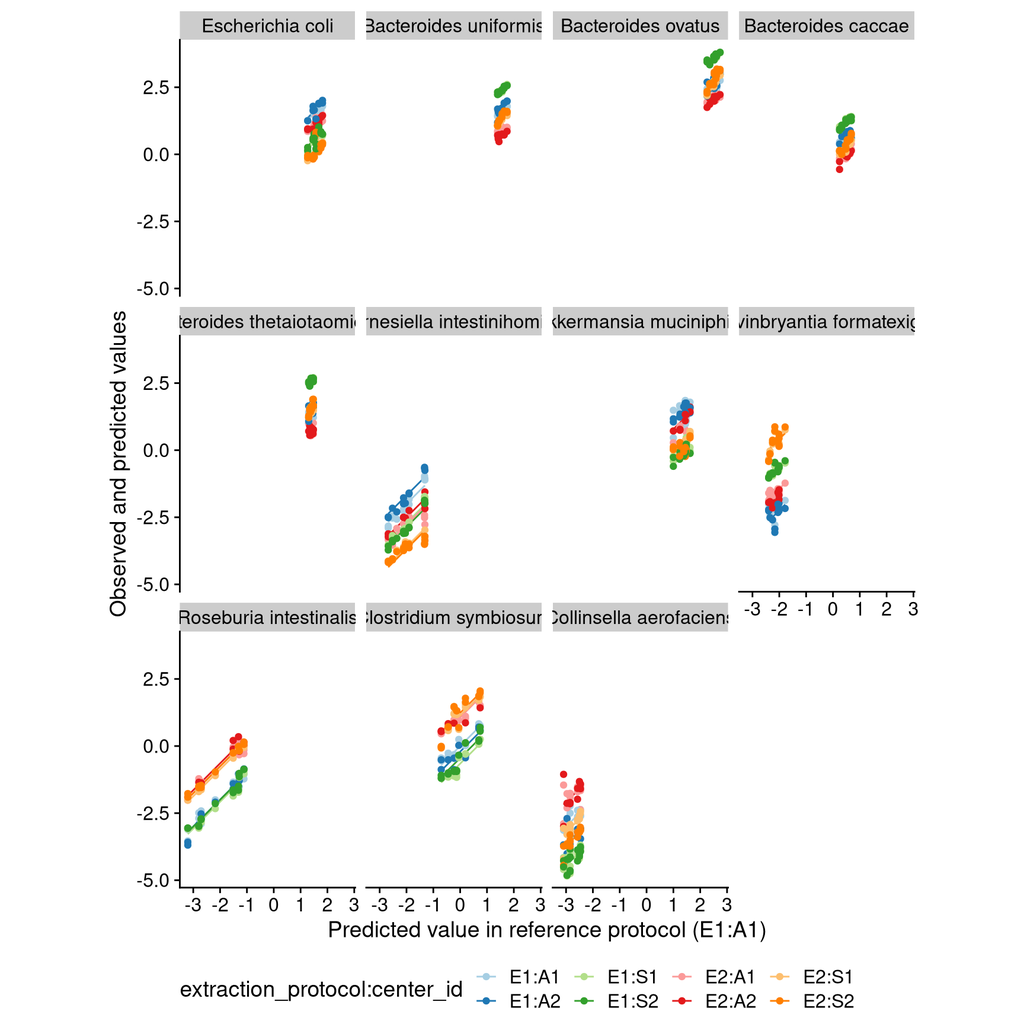

It is also useful to zoom in on the relevant range for each taxon,

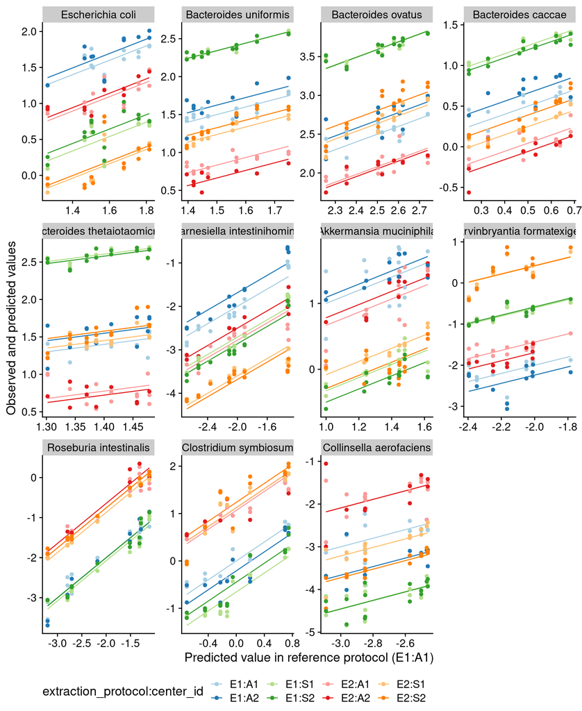

An alternative could perhaps be to color by taxon and facet by protocol.

TODO: Add plot of residuals vs. fitted values; can borrow code from other doc

## Sequencing type vs. center, across extraction protocols and batches

TODO: * include E. rectale, but adjust denominator to exclude it

Of interest is whether the difference between library strategies (Shotgun vs. Amplicon) is larger than the difference between sequencing centers using the same strategy (A1/A2, and S1/S2). To allow for the possibility that the bias associated with sequencing protocol varies by extraction protocol and batch, I will estimate the effect of sequencing center separately within the 4 extraction batch and protocol combinations.

```
observed =
  sum_j alpha_j I(specimen_id == j)
  + beta_1 I(library_strategy == "Shotgun")
  + beta_2 I(center_id == "A2")
  + beta_3 I(center_id == "S2")
  + noise
```

where `j` indexes the various specimens and `library_strategy` has the value “Amplicon” for samples from centers A1 and A2 and “Shotgun” for samples from centers “S1” and “S2”. So the terms represent

- `alpha_j` is the CLR value for the taxon as measured by Center A1
- `beta_1` is the differential bias A1:S1
- `beta_2` is the differential bias A2:A1
- `beta_3` is the differential bias S2:S1

Are the sequencing biases consistent across extraction batch and protocol?

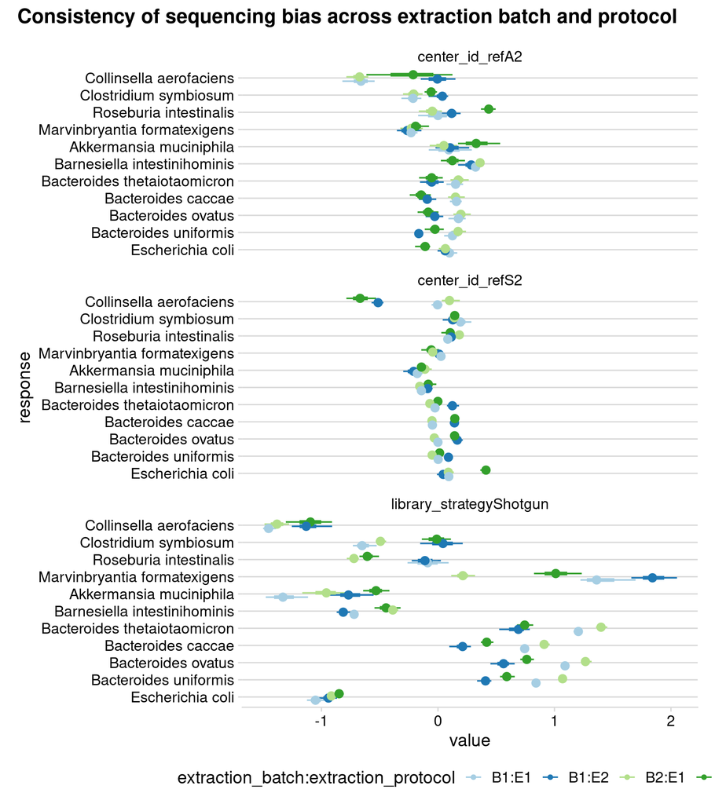

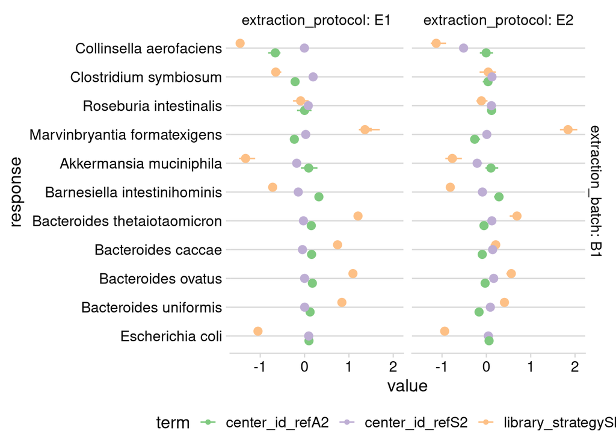

Can see that the Shotgun-vs-Amplicon bias vector is much larger than the bias within each methodology.

Possible visualizations for the pairwise bias values (all pairs of taxa): If we just use the point estimate, then we can use a dotplot:

Notes

- Ultimately, I suspect it will be better to show a shotgun effect that is the difference between the average A and the average S bias, rather than the difference between A1 and A2
- Should compare the S/A bias to the prediction (assembly size) / (16S copy number)

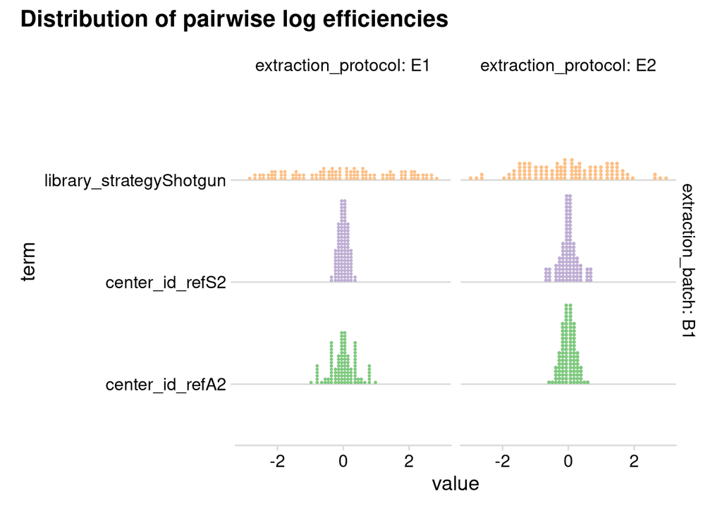

### Genomic explanation?

Compare the S/A bias to genomic expectation `ssu_count / reference_genome_size`,

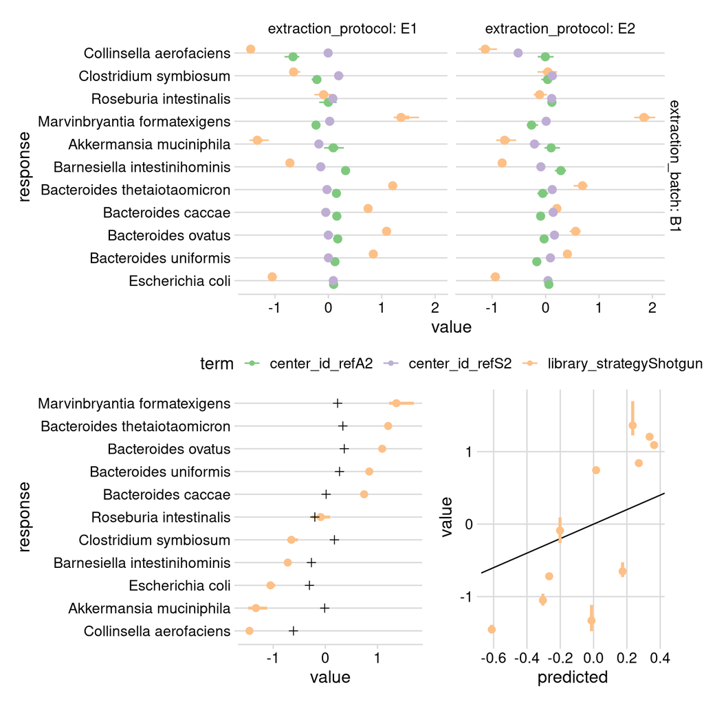

- The variation within Bacteroides can be largely explained by the predicted genomic bias.
- E. coli S/A bias is lower than the prediction - this is somewhat expected, since the genomic prediction does not account for the fact that we are throwing out reads that align to both the Nissle and HS genomes. Not sure about the expected magnitude of this effect, however.

TODO: Calculate the fraction of S/A bias explained by the genomic prediction.